# Ford Go Bike Trip Data Exploration Presentation

## by Robert Kimani Chege

## Investigation Overview

From my exploration, I found out that trips taking long durations are less frequent with the most frequent trips being averagely 500 seconds. Participants in these bike trips are mostly between 20 to 45 years with the highest number being in their mid 30's. It's interesting that the most common start stations are also the most common end stations. Among the user types, subscribers are the majority being approximately 90% and the rest customers. Majority are of the male gender, followed by female then the other genders. 90% of the members do not share their bikes, however it's interesting that they also spend the longest time in their trips. Those sharing their bikes are only subscribers and likely to be in the age bracket 20 to 30 years. The other gender has a record of longer trip durations as compared to the male and female genders.

### Overall Goals of The Presentation

My key insights for presentation will be each gender's trip duration in relation to user types and bike shares categories and bike shares among user types. I will use point plots and scatter plots for the former and a countplot for the latter.

## Dataset Overview

This dataset includes information about 174,877 individual bike rides made in a bike-sharing system covering the greater San Francisco Bay area. The properties of the individual bike rides include: trip duration in seconds and minutes, trip start and end time, start and end station names, bike shares, user type, gender and age of members.

## Frequency Of Bike Sharing Among User Types

The visualization below represents the number of user types involved in bike sharing. It is evident none of the customers is involved in bike sharing througout all the trips.

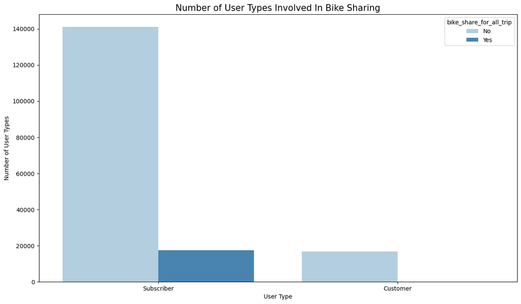

## Correlation of Age With Trip Duration For Each Bike Share Category

From the visualization below it is clear that for both bike share categories, there is a negative correlation between member age and trip duration, however, it is key to note that majority of the members who shared their bikes though a small proportion compared to the other avoid longer duration trips.

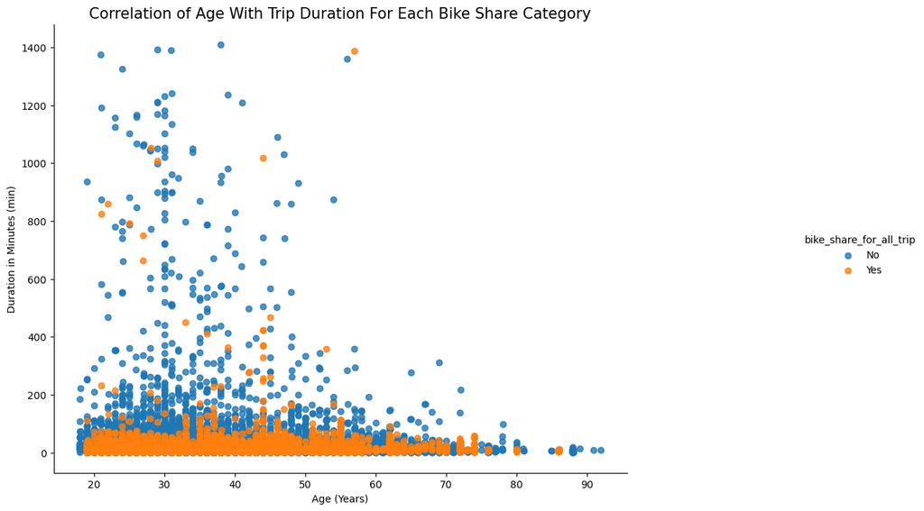

## Trip Durations Across Bike Share Categories For Each Gender

The below visualization illustrates how different gender spend time in their trips with regard to whether they are involved in bike sharing or not. It is evident that across all genders those not involved in bike sharing have the longest durations. It is also key to note that the other gender averagely spends more time in their trips, followed by females then males.  
It is also important to note that among the male and female genders, there's an almost equal level in trip duration for both bike share levels while for the other gender those who do not share bikes take significantly more time in their trips.

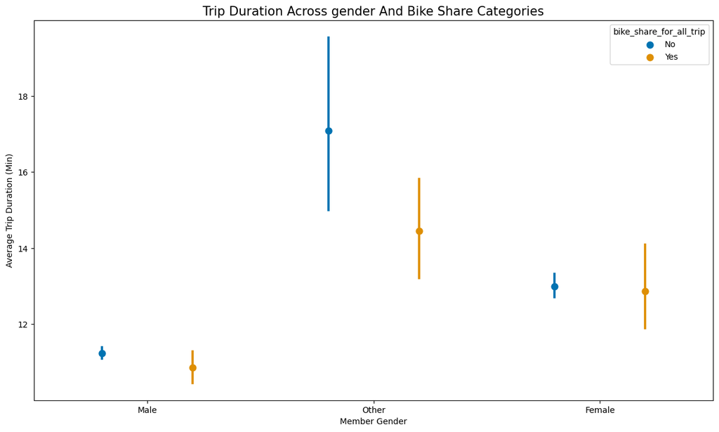

## Trip Durations Across Bike User Types In Each Gender

The below visualization illustrates how different gender spend time in their trips with regard to whether they are customers or subscribers. It is evident that across all genders customers spend quite a significant time in their trips. The trend of the other gender having the longest durations, followed by female then male is also evident.

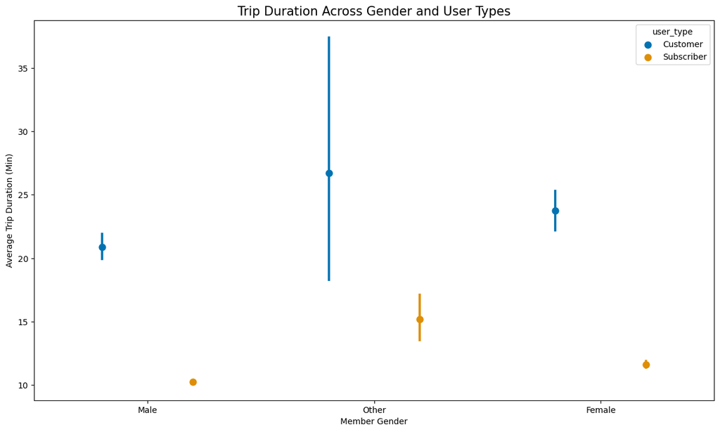